# Домашнее задание №2

2023-11-01

# Часть 1

```r
ME <- read_dta("RAPDC_lab3.dta")
ME$state_id <- as.factor(ME$state)
ME <- na.omit(ME)
```

```r
model4.2.1 <- lmer(votepct ~ money + acres + party + (1 + party|state_id), REML = FALSE, data = ME)
state_unique <- unique(ME$state_id)
```

### Краткое описание данных

- state - штат (группирующая переменная).
- lastname - член Конгресса

**Переменные на первом уровне:**

- votepct - доля голосов, отданных членом Конгресса в поддержку табачной индустрии (зависимая переменная).
- party - дамми-переменная: представитель Демократической или Республиканской партии (1 - Республиканская партия)
- money - размер финансирования от PAC табачных корпораций (в тысячах долларов)

**Предиктор на втором уровне:**

- acres - площадь табачных плантаций (в тысячах акров).

# Задание 1

Определим по модели 4.2.1, для каких штатов значение меры Кука достаточно высокое, выходит за приемлемые границы, что указывает на влиятельность наблюдений.

```r
inf <- influence(model4.2.1, group = "state_id", data = ME)
cooks.distance.estex(inf, sort=TRUE)
```

```
##           [,1]
## HI 0.001217661
## AZ 0.001411733
## NH 0.001579654
## NV 0.003029974
## AK 0.003049995
## ND 0.003386937
## OR 0.003928506
## SD 0.004243326
## WV 0.004385738
## MT 0.004964767
## WY 0.005544986
## GA 0.005819324
## NE 0.006892953
## ID 0.007197633
## WA 0.007318332
## NM 0.007731376
## MN 0.007834657
## OH 0.010019280
## CO 0.010087407
## KS 0.012425073
## VA 0.015032938
## IL 0.015375153
## RI 0.015739676
## IN 0.015836567
## FL 0.015999107
## OK 0.016102770
## VT 0.016125567
## LA 0.016264229
## UT 0.016534082
## MA 0.016677455
## AR 0.016915885
## MD 0.019763735
## MI 0.025390620
## WI 0.025992456
## NY 0.026063781
## PA 0.026110747
## MS 0.026955503
## SC 0.031873206
## CT 0.032825236
## TN 0.032827785
## IA 0.039443721
## TX 0.042176283
## DE 0.042460790
## MO 0.049419741
## ME 0.056475249
## NC 0.062552613
## AL 0.124653048
## CA 0.147008538
## KY 0.177384662
## NJ 0.214744837
```

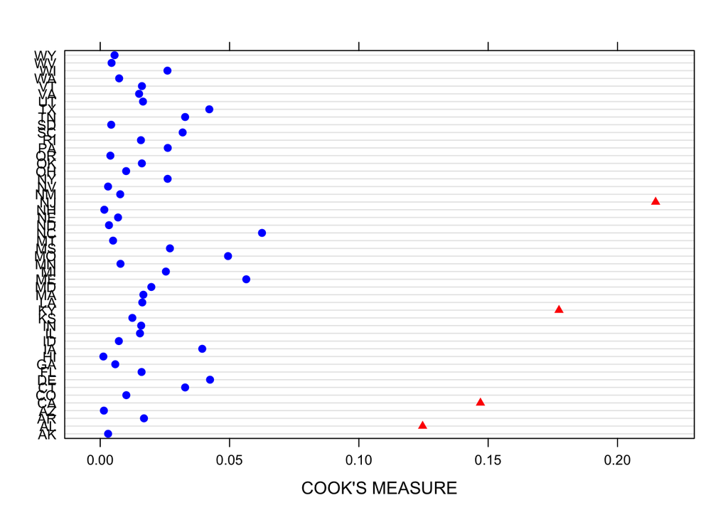

```r
plot(inf, which = "cook", xlab = "COOK'S MEASURE", cutoff = 4/length(state_unique))
```

Для модели 4.2.1 влиятельными наблюдениями являются штаты Алабама, Калифорния, Кентукки, Нью-Джерси (AL, CA, KY, NJ).

Сравним результаты – оценки модели – на усеченной выборке с оценками на полной выборке – исходной модели.

```r
summary(model4.2.1)
```

```
## Linear mixed model fit by maximum likelihood . t-tests use Satterthwaite's
##   method [lmerModLmerTest]
## Formula: votepct ~ money + acres + party + (1 + party | state_id)
##    Data: ME
##
##      AIC      BIC   logLik deviance df.resid
##   -312.0   -277.8    164.0   -328.0      519
##
## Scaled residuals:
##     Min      1Q  Median      3Q     Max
## -3.7460 -0.5764 -0.0002  0.5632  4.5800
##
## Random effects:
##  Groups   Name        Variance Std.Dev. Corr
##  state_id (Intercept) 0.010816 0.10400
##           party       0.008485 0.09211  -0.73
##  Residual             0.027284 0.16518
## Number of obs: 527, groups:  state_id, 50
##
## Fixed effects:
##              Estimate Std. Error        df t value Pr(>|t|)
## (Intercept) 2.048e-01  2.093e-02 3.473e+01   9.782 1.63e-11 ***
## money       4.065e-03  4.947e-04 5.109e+02   8.217 1.73e-15 ***
## acres       5.924e-04  3.174e-04 3.700e+01   1.866   0.0699 .
## party       4.882e-01  2.222e-02 3.790e+01  21.977  < 2e-16 ***
## ---
## Signif. codes:  0 '***' 0.001 '**' 0.01 '*' 0.05 '.' 0.1 ' ' 1
##
## Correlation of Fixed Effects:
##       (Intr) money  acres
## money -0.164
## acres -0.142 -0.325
## party -0.669 -0.137 -0.001
```

```r
tr_data <- subset(ME, state_id !='AL' & state_id !='CA' & state_id !='KY' & state_id !='NJ')
tr_data <- na.omit(tr_data)
tr_model <- lmer(votepct ~ money + acres + party + (1 + party|state_id), REML = FALSE, data = tr_data)
summary(tr_model)
```

```
## Linear mixed model fit by maximum likelihood . t-tests use Satterthwaite's
##   method [lmerModLmerTest]
## Formula: votepct ~ money + acres + party + (1 + party | state_id)
##    Data: tr_data
##
##      AIC      BIC   logLik deviance df.resid
##   -294.2   -261.4    155.1   -310.2      433
##
## Scaled residuals:
##     Min      1Q  Median      3Q     Max
## -3.3796 -0.5899 -0.0077  0.5981  3.8076
##
## Random effects:
##  Groups   Name        Variance Std.Dev. Corr
##  state_id (Intercept) 0.009203 0.09593
##           party       0.004646 0.06816  -0.70
##  Residual             0.025295 0.15904
## Number of obs: 441, groups:  state_id, 46
##
## Fixed effects:
##              Estimate Std. Error        df t value Pr(>|t|)
## (Intercept) 1.934e-01  2.057e-02 4.004e+01   9.402 1.10e-11 ***
## money       4.042e-03  5.067e-04 4.250e+02   7.979 1.39e-14 ***
## acres       6.845e-04  4.047e-04 2.685e+01   1.691    0.102
## party       5.017e-01  2.055e-02 3.669e+01  24.415  < 2e-16 ***
## ---
## Signif. codes:  0 '***' 0.001 '**' 0.01 '*' 0.05 '.' 0.1 ' ' 1
##
## Correlation of Fixed Effects:
##       (Intr) money  acres
## money -0.172
## acres -0.175 -0.266
## party -0.630 -0.153  0.006
```

Мы потеряли данные для четырех единиц на втором уровне (что достаточно много), но значимых изменений не заметили. Следовательно, не стоит избавляться от этих наблюдений.

# Задание 2

Предложим способы работы с влиятельными наблюдениями в моделях со смешанными эффектами. Так как штаты – более крупные единицы анализа (второй уровень) – и содержат целую группу наблюдений, то удалять их было бы не совсем корректно.

Для решения проблемы влиятельных наблюдений можно включить фиктивные переменные с фиксированным эффектом на более высоких уровнях. Можно создать подгруппы штатов и анализировать данные на уровне подгрупп (включить в модель дамми-переменные для подгрупп с влиятельными наблюдениями). Это позволит сохранить информацию и учесть различия между штатами. Можно использовать класстеризацию, где наблюдения разделяются на группы на основе их сходства. Влиятельные наблюдения могут быть отнесены к отдельному классу, и анализ может быть проведен с учетом этой группировки.

Если модель основана на небольшой выборке и если это возможно, то следует расширить выборку. Возможно, в большей выборке будет больше наблюдений похожих на наши влиятельные наблюдения и они больше не будут оказывать такого влияния.

Также можно изменить спецификацию модели. Возможно, существенные воздействующие факторы были выделены неверно. Если влиятельных наблюдений много, то, возможно, была предложена неверная функциональная форма модели (например, нелинейная взаимосвязь смоделирована неверно).

Также следует проверить точность процесса сбора данных, проверить, не было ли допущено ошибок измерения, проверить согласованность данных, чтобы гарантировать, что влиятельные наблюдения не появились в данных из-за ошибки на этом этапе.

# Задание 3

Определим по модели 4.2.1, для каких штатов значение меры DFBETA достаточно высокое, выходит за приемлемые границы, что указывает на влиятельность наблюдений.

```r
estex.model4.2.1 <- influence(model4.2.1, "state_id")
dfbetas(estex.model4.2.1)
```

```
##    (Intercept)         money        acres        party
## AK  0.03337195 -0.0828935541 -0.033540598  0.033901535
## AL  0.57485960 -0.0573508115 -0.475465682 -0.251459323
## AR  0.21942679 -0.0791078859 -0.124698292 -0.067549329
## AZ  0.03516439 -0.0045258068 -0.062660976  0.005868468
## CA -0.27434944  0.6615646615 -0.222642228  0.277865759
## CO -0.02526548 -0.0493766145  0.013667715  0.160933951
## CT -0.23482387  0.0350516787  0.132421373 -0.021013519
## DE -0.12707078 -0.0678436921  0.275346706 -0.125890920
## FL -0.01562270  0.2503702000 -0.110088209 -0.050054728
## GA -0.06616125  0.0860145477 -0.033993217  0.105740212
## HI -0.03759939  0.0240688509  0.050618060  0.008085654
## IA -0.14399282  0.3100241879  0.050550987 -0.118852267
## ID  0.06242652 -0.0785781905 -0.051291806  0.073577340
## IL -0.08289631  0.1001118477 -0.091122468  0.186903716
## IN  0.02779595  0.1090013799  0.008260470  0.081103784
## KS  0.16249512 -0.1224565468 -0.083982140 -0.021246006
## KY  0.44420471 -0.6816006029 -0.114477941 -0.276080545
## LA  0.14681021  0.0007007135 -0.104790812  0.036625048
## MA -0.24900450 -0.0008505556  0.012576786  0.164486881
## MD -0.17783322  0.1715063574  0.027845125 -0.025188766
## ME -0.15767268  0.0903169149  0.282158453 -0.169488381
## MI -0.07635506 -0.2505867762  0.017080220  0.221232209
## MN -0.01213301  0.0653485244  0.080238159 -0.110092433
## MO  0.36556391  0.0484278989 -0.303550974 -0.196997017
## MS  0.26869907 -0.0284504528 -0.181176311 -0.075757443
## MT -0.05164473 -0.1069434367  0.066001906  0.021675061
## NC  0.30934108 -0.3203284825 -0.107507416 -0.265508318
## ND -0.10750489 -0.0006254410  0.059360472  0.066711329
## NE -0.06348675 -0.0854322883 -0.029955858  0.142428594
## NH  0.02833590 -0.0228255590 -0.052907318  0.025523167
## NJ -0.16415481  0.1534100077  0.627530356 -0.388081224
## NM -0.06216830 -0.0213617026  0.007316608  0.160393974
## NV -0.10605955 -0.0051969388  0.040752048  0.072707896
## NY -0.20350421 -0.0730092564 -0.083321122  0.298556090
## OH -0.07808207 -0.0828867448  0.075546051 -0.030664848
## OK  0.07133043 -0.1315243635  0.121066804  0.091067074
## OR -0.08597848  0.0162069203 -0.005069674  0.120654321
## PA  0.01838555 -0.3085405694  0.089298993  0.006115095
## RI -0.22097455  0.0378907336  0.046563389  0.067938328
## SC  0.14691956 -0.2171989804  0.252101236  0.002064221
## SD -0.12921105  0.0161316641  0.028149505  0.077528617
## TN  0.11180135  0.3074184133 -0.059074386 -0.224914166
## TX  0.30981725  0.0457255315 -0.299962368 -0.123991499
## UT -0.08883625  0.0664699511  0.112667612 -0.111015915
## VA  0.21161967  0.0780840430 -0.037586850 -0.198841262
## VT -0.14406858  0.0665980960  0.112015840 -0.045877025
## WA -0.15871124  0.0633598995 -0.026023036  0.127247406
## WI -0.19749943  0.0494404368  0.041982323  0.293704286
## WV  0.08062086  0.0873520870 -0.022036217 -0.084837444
## WY  0.05135150 -0.0125143785 -0.065909632  0.064337177
```

В нашем случае приемлемая граница равна

$$\frac{2}{\sqrt(n)} = \frac{2}{\sqrt(50)} = 0.28284271247 ≈ 0.28$$

Для переменной money значение меры DFBETA выходит за приемлемые границы для штатов *KY, CA* (значение высокое - 0.68 и 0.66 соответственно),TN, PA, NC, IA (значение меры DFBETA немного превышает приемлемую границу), что указывает на влиятельность этих наблюдений.

Для предиктора acres значение меры DFBETA выходит за приемлемые границы для штатов *NJ, AL* (значение высокое - 0.62 и 0.48 соответственно)*,* MO, TX (значение меры DFBETA немного превышает приемлемую границу), что указывает на влиятельность этих наблюдений.

Для переменной party значение меры DFBETA выходит за приемлемые границы для штата *NJ* (значение высокое - 0.38) , NY, WI (значение меры DFBETA немного превышает приемлемую границу и равно 0.30 для обоих штатов), что указывает на влиятельность этих наблюдений.

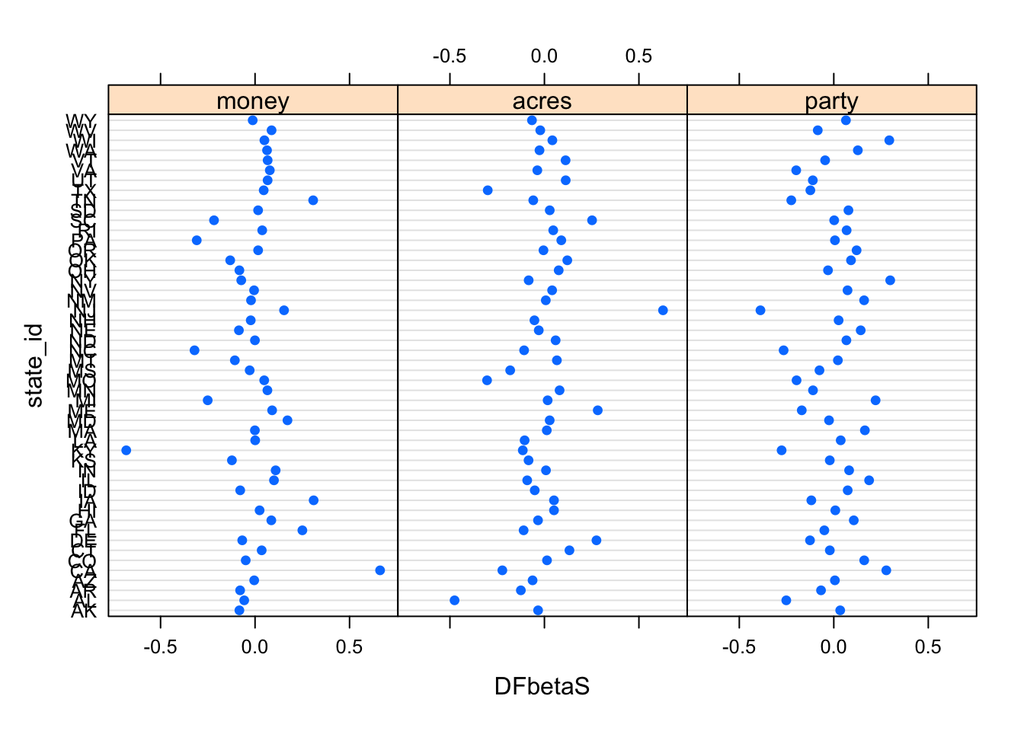

```r
plot(estex.model4.2.1,
    which="dfbetas",
    parameters=c(2,3,4),
    xlab="DFbetaS",
    ylab="state_id")
```

По графику видно, что для переменной money значение меры DFBETA выходит за приемлемые границы для штатов *KA, KY*, для предиктора acres - для штатов *AL, NJ,* что указывает на этих влиятельность наблюдений. Это те же влиятельные наблюдения, которые были выявлены по мере Кука.

Сравним по каждому параметру результаты – оценки модели – на усеченной выборке с оценками на полной выборке – исходной модели.

```r
estex.model4.3 <- influence(tr_model, "state_id")
dfbetas(estex.model4.3, parameters=c(2,3,4))
```

```
##            money        acres        party
## AK -0.0923213950 -0.037275796  0.036390504
## AR -0.0898579043 -0.139123792 -0.084264306
## AZ -0.0063435129 -0.068347818 -0.008280774
## CO -0.0507585184  0.019649107  0.176833437
## CT  0.0518447297  0.164705116 -0.047936541
## DE -0.0731958619  0.298869244 -0.138539697
## FL  0.2801397908 -0.113635941 -0.115699719
## GA  0.0950959296 -0.026361289  0.101638308
## HI  0.0232899900  0.046241887 -0.004645549
## IA  0.3340849208  0.088364340 -0.163194490
## ID -0.0872270164 -0.055630138  0.075485169
## IL  0.1087725061 -0.111802478  0.190882440
## IN  0.1205681493  0.043003010  0.074998750
## KS -0.1357150351 -0.093380116 -0.029332864
## LA -0.0037064269 -0.117761799  0.012356553
## MA  0.0074446094  0.031497287  0.183734084
## MD  0.1912140416  0.041950825 -0.071739613
## ME  0.1115126474  0.317752765 -0.196730336
## MI -0.2870437721 -0.005916898  0.251098988
## MN  0.0556769392  0.084923210 -0.154131536
## MO  0.0675087944 -0.347766069 -0.246432767
## MS -0.0334330853 -0.194761221 -0.101873889
## MT -0.1192403734  0.066232668  0.017867347
## NC -0.2775851151 -1.184524361 -0.289018546
## ND -0.0009521099  0.061300358  0.060136150
## NE -0.0982663806 -0.036384523  0.153332401
## NH -0.0251790879 -0.051645671  0.027714249
## NM -0.0262123511  0.007991963  0.173012003
## NV -0.0073931745  0.043847774  0.066343802
## NY -0.0873811286 -0.101570654  0.442360220
## OH -0.1022925723  0.094574066 -0.081184156
## OK -0.1419305937  0.177194674  0.092929784
## OR  0.0104603710 -0.012133921  0.115114425
## PA -0.3604634334  0.078018140 -0.065793623
## RI  0.0439687252  0.068569814  0.059820789
## SC -0.2326809945  0.335167072 -0.012754386
## SD  0.0161904491  0.034160425  0.073024467
## TN  0.4100685286 -0.051622932 -0.297580883
## TX  0.0194900171 -0.375182088 -0.205478592
## UT  0.0797586733  0.140155631 -0.119448035
## VA  0.0949990692 -0.016514568 -0.252418688
## VT  0.0742647559  0.126087350 -0.061112454
## WA  0.0688226120 -0.021886879  0.136774406
## WI  0.0576701159  0.069434174  0.380531874
## WV  0.0939568782 -0.039523615 -0.105591679
## WY -0.0136578911 -0.066698372  0.064163480
```

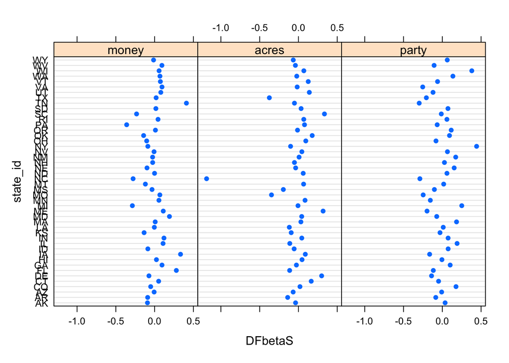

```r
plot(estex.model4.3,
     which="dfbetas",
     parameters=c(2,3,4),
     xlab="DFbetaS",
     ylab="state_id")
```

```r
dfbetas(estex.model4.3, parameters=c(2,3,4))
```

```
##            money        acres        party
## AK -0.0923213950 -0.037275796  0.036390504
## AR -0.0898579043 -0.139123792 -0.084264306
## AZ -0.0063435129 -0.068347818 -0.008280774
## CO -0.0507585184  0.019649107  0.176833437
## CT  0.0518447297  0.164705116 -0.047936541
## DE -0.0731958619  0.298869244 -0.138539697
## FL  0.2801397908 -0.113635941 -0.115699719
## GA  0.0950959296 -0.026361289  0.101638308
## HI  0.0232899900  0.046241887 -0.004645549
## IA  0.3340849208  0.088364340 -0.163194490
## ID -0.0872270164 -0.055630138  0.075485169
## IL  0.1087725061 -0.111802478  0.190882440
## IN  0.1205681493  0.043003010  0.074998750
## KS -0.1357150351 -0.093380116 -0.029332864
## LA -0.0037064269 -0.117761799  0.012356553
## MA  0.0074446094  0.031497287  0.183734084
## MD  0.1912140416  0.041950825 -0.071739613
## ME  0.1115126474  0.317752765 -0.196730336
## MI -0.2870437721 -0.005916898  0.251098988
## MN  0.0556769392  0.084923210 -0.154131536
## MO  0.0675087944 -0.347766069 -0.246432767
## MS -0.0334330853 -0.194761221 -0.101873889
## MT -0.1192403734  0.066232668  0.017867347
## NC -0.2775851151 -1.184524361 -0.289018546
## ND -0.0009521099  0.061300358  0.060136150
## NE -0.0982663806 -0.036384523  0.153332401
## NH -0.0251790879 -0.051645671  0.027714249
## NM -0.0262123511  0.007991963  0.173012003
## NV -0.0073931745  0.043847774  0.066343802
## NY -0.0873811286 -0.101570654  0.442360220
## OH -0.1022925723  0.094574066 -0.081184156
## OK -0.1419305937  0.177194674  0.092929784
## OR  0.0104603710 -0.012133921  0.115114425
## PA -0.3604634334  0.078018140 -0.065793623
## RI  0.0439687252  0.068569814  0.059820789
## SC -0.2326809945  0.335167072 -0.012754386
## SD  0.0161904491  0.034160425  0.073024467
## TN  0.4100685286 -0.051622932 -0.297580883
## TX  0.0194900171 -0.375182088 -0.205478592
## UT  0.0797586733  0.140155631 -0.119448035
## VA  0.0949990692 -0.016514568 -0.252418688
## VT  0.0742647559  0.126087350 -0.061112454
## WA  0.0688226120 -0.021886879  0.136774406
## WI  0.0576701159  0.069434174  0.380531874
## WV  0.0939568782 -0.039523615 -0.105591679
## WY -0.0136578911 -0.066698372  0.064163480
```

Видно, что для предиктора acres значение меры DFBETA сильнее всего выходит за приемлемые границы для штата NC (-1.18), а также высоко для штата TX (-0.38). Для переменной money значение меры DFBETA выходит за приемлемые границы для штатов TN (0.41) и PA (-0.36). Для переменной party значение меры DFBETA выходит за приемлемые границы для штатов NY (0.44) и WI (0.38). Из данных наблюдений NC самый влиятельный, остальные не так сильно превышают пороговое значение. Попробуем его убрать.

```r
ME_2 <- subset(ME, state_id != "NC")
model4.4 <- lmer(votepct ~ money + acres + party + (1 + party|state_id), REML = FALSE, data = ME_2)
summary (model4.4 )
```

```
## Linear mixed model fit by maximum likelihood . t-tests use Satterthwaite's
##   method [lmerModLmerTest]
## Formula: votepct ~ money + acres + party + (1 + party | state_id)
##    Data: ME_2
##
##      AIC      BIC   logLik deviance df.resid
##   -300.5   -266.6    158.3   -316.5      506
##
## Scaled residuals:
##     Min      1Q  Median      3Q     Max
## -3.7028 -0.5851 -0.0043  0.5652  4.5269
##
## Random effects:
##  Groups   Name        Variance Std.Dev. Corr
##  state_id (Intercept) 0.010105 0.10053
##           party       0.007104 0.08429  -0.70
##  Residual             0.027643 0.16626
## Number of obs: 514, groups:  state_id, 49
##
## Fixed effects:
##              Estimate Std. Error        df t value Pr(>|t|)
## (Intercept) 1.984e-01  2.070e-02 3.547e+01   9.586 2.21e-11 ***
## money       4.229e-03  5.106e-04 5.004e+02   8.281 1.12e-15 ***
## acres       6.381e-04  4.248e-04 3.708e+01   1.502    0.142
## party       4.940e-01  2.180e-02 3.547e+01  22.667  < 2e-16 ***
## ---
## Signif. codes:  0 '***' 0.001 '**' 0.01 '*' 0.05 '.' 0.1 ' ' 1
##
## Correlation of Fixed Effects:
##       (Intr) money  acres
## money -0.168
## acres -0.140 -0.269
## party -0.652 -0.144 -0.016
```

Значимым образом результаты не изменились. Таким образом, и по мере Кука и по мере DFBETA результаты получились похожие. Были выявлены четыре влиятельных наблюдения, однако результаты на усеченной выборке и на полной выборке значимым образом не отлчиаются.

# Задание 4

Проверим, можно ли говорить о нормальности распределения ошибок первого уровня и случайных эффектов, с помощью формальных тестов. Воспользуемся тестом Шапиро-Уилка. Нам он подходит, так как выборка относительно небольшая.

```r
shapiro.test(residuals(model4.2.1))
```

```
##
##  Shapiro-Wilk normality test
##
## data:  residuals(model4.2.1)
## W = 0.98217, p-value = 4.691e-06
```

Нулевая гипотеза: выборка взята из нормального распределения с некоторыми параметрами. P-value ≈ 0, следовательно, эту гипотезу следует отвергнуть. Следовательно, условие о нормальности остатков модели стоит отвергнуть.

Можно провести аналогичный тест для каждого случайного эффекта.

```r
shapiro.test(ranef(model4.2.1)$state_id[, 2])
```

```
##
##  Shapiro-Wilk normality test
##
## data:  ranef(model4.2.1)$state_id[, 2]
## W = 0.97903, p-value = 0.512
```

```r
shapiro.test(ranef(model4.2.1)$state_id[, 1])
```

```
##
##  Shapiro-Wilk normality test
##
## data:  ranef(model4.2.1)$state_id[, 1]
## W = 0.97129, p-value = 0.261
```

```r
shapiro.test(resid(tr_model))
```

```
##
##  Shapiro-Wilk normality test
##
## data:  resid(tr_model)
## W = 0.98965, p-value = 0.003344
```

На усеченной выборке результаты стали лучше.

Для большего приближения к нормальному распределению можно удалить влиятельные наблюдения (однако это не является лучшим вариантом из-за потери информации). Также можно расширить выборку, логарифмировать переменные, применить метод робастного оценивания.

# Задание 5

Авторов оригинального исследования интересовало, есть ли различия во взаимосвязи размера финансирования комитетами политического действия (PAC) от табачных корпораций и голосования в интересах табачной индустрии между представителями Демократической и Республиканской партий.

Протестируем, есть ли обозначенные различия между представителями Демократической и Республиканской партий, уточнив спецификацию модели.

Добавим переменную взаимодействия двух переменных первого уровня: party и money.

```r
new_model <- lmer(votepct ~ party + money + party * money + (1 + party | state), data = ME)
summary(new_model)
```

```
## Linear mixed model fit by REML. t-tests use Satterthwaite's method [
## lmerModLmerTest]
## Formula: votepct ~ party + money + party * money + (1 + party | state)
##    Data: ME
##
## REML criterion at convergence: -314
##
## Scaled residuals:
##     Min      1Q  Median      3Q     Max
## -3.8925 -0.5828  0.0170  0.5451  4.2184
##
## Random effects:
##  Groups   Name        Variance Std.Dev. Corr
##  state    (Intercept) 0.007989 0.08938
##           party       0.004327 0.06578  -0.55
##  Residual             0.026604 0.16311
## Number of obs: 527, groups:  state, 50
##
## Fixed effects:
##               Estimate Std. Error         df t value Pr(>|t|)
## (Intercept)  1.752e-01  1.953e-02  3.873e+01   8.971 5.38e-11 ***
## party        5.514e-01  2.248e-02  5.397e+01  24.523  < 2e-16 ***
## money        7.745e-03  7.599e-04  2.793e+02  10.193  < 2e-16 ***
## party:money -5.059e-03  9.167e-04  3.282e+02  -5.519 6.94e-08 ***
## ---
## Signif. codes:  0 '***' 0.001 '**' 0.01 '*' 0.05 '.' 0.1 ' ' 1
##
## Correlation of Fixed Effects:
##             (Intr) party  money
## party       -0.629
## money       -0.378  0.316
## party:money  0.299 -0.505 -0.795
```

```r
new_model_2 <- lmer(votepct ~ party + money + acres + party * money + (1 + party | state), data = ME)
summary(new_model_2)
```

```
## Linear mixed model fit by REML. t-tests use Satterthwaite's method [
## lmerModLmerTest]
## Formula: votepct ~ party + money + acres + party * money + (1 + party |
##     state)
##    Data: ME
##
## REML criterion at convergence: -304.5
##
## Scaled residuals:
##     Min      1Q  Median      3Q     Max
## -3.9307 -0.5789  0.0196  0.5359  4.2653
##
## Random effects:
##  Groups   Name        Variance Std.Dev. Corr
##  state    (Intercept) 0.00701  0.08373
##           party       0.00471  0.06863  -0.49
##  Residual             0.02644  0.16261
## Number of obs: 527, groups:  state, 50
##
## Fixed effects:
##               Estimate Std. Error         df t value Pr(>|t|)
## (Intercept)  1.674e-01  1.912e-02  4.020e+01   8.752 7.47e-11 ***
## party        5.523e-01  2.264e-02  5.375e+01  24.394  < 2e-16 ***
## money        7.483e-03  7.691e-04  3.408e+02   9.729  < 2e-16 ***
## acres        7.059e-04  3.198e-04  3.952e+01   2.207   0.0332 *
## party:money -5.134e-03  9.147e-04  3.315e+02  -5.613 4.21e-08 ***
## ---
## Signif. codes:  0 '***' 0.001 '**' 0.01 '*' 0.05 '.' 0.1 ' ' 1
##
## Correlation of Fixed Effects:
##             (Intr) party  money  acres
## party       -0.609
## money       -0.341  0.306
## acres       -0.156 -0.003 -0.204
## party:money  0.300 -0.501 -0.777  0.002
```

Сравним модели:

```r
anova(new_model, new_model_2)
```

```
## Data: ME
## Models:
## new_model: votepct ~ party + money + party * money + (1 + party | state)
## new_model_2: votepct ~ party + money + acres + party * money + (1 + party | state)
##             npar     AIC     BIC logLik deviance  Chisq Df Pr(>Chisq)
## new_model      8 -336.54 -302.40 176.27  -352.54
## new_model_2    9 -339.33 -300.92 178.66  -357.33 4.7863  1    0.02869 *
## ---
## Signif. codes:  0 '***' 0.001 '**' 0.01 '*' 0.05 '.' 0.1 ' ' 1
```

```r
summary(new_model)
```

```
## Linear mixed model fit by REML. t-tests use Satterthwaite's method [
## lmerModLmerTest]
## Formula: votepct ~ party + money + party * money + (1 + party | state)
##    Data: ME
##
## REML criterion at convergence: -314
##
## Scaled residuals:
##     Min      1Q  Median      3Q     Max
## -3.8925 -0.5828  0.0170  0.5451  4.2184
##
## Random effects:
##  Groups   Name        Variance Std.Dev. Corr
##  state    (Intercept) 0.007989 0.08938
##           party       0.004327 0.06578  -0.55
##  Residual             0.026604 0.16311
## Number of obs: 527, groups:  state, 50
##
## Fixed effects:
##               Estimate Std. Error         df t value Pr(>|t|)
## (Intercept)  1.752e-01  1.953e-02  3.873e+01   8.971 5.38e-11 ***
## party        5.514e-01  2.248e-02  5.397e+01  24.523  < 2e-16 ***
## money        7.745e-03  7.599e-04  2.793e+02  10.193  < 2e-16 ***
## party:money -5.059e-03  9.167e-04  3.282e+02  -5.519 6.94e-08 ***
## ---
## Signif. codes:  0 '***' 0.001 '**' 0.01 '*' 0.05 '.' 0.1 ' ' 1
##
## Correlation of Fixed Effects:
##             (Intr) party  money
## party       -0.629
## money       -0.378  0.316
## party:money  0.299 -0.505 -0.795
```

Визуализируем различия или их отсутствие: посмотрим какая взаимосвязь наблюдается среди представителей Демократической и Республиканской партий.

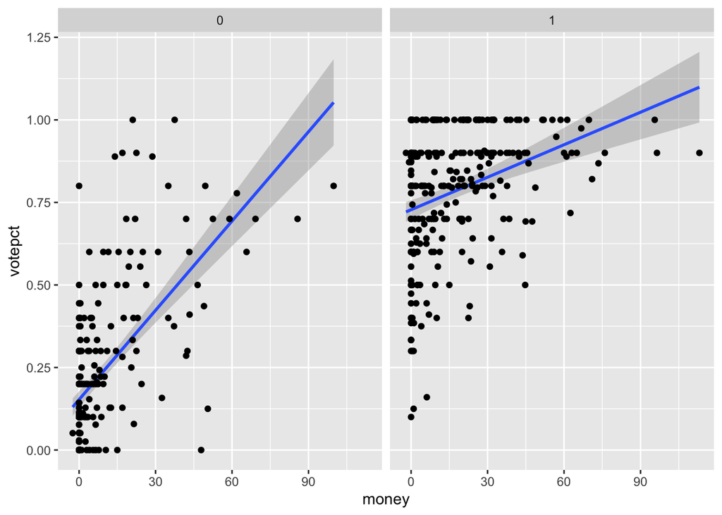

```r
ggplot(ME, aes(x = money, y = votepct)) +
  geom_smooth(method = "lm") +
  geom_point() +
  facet_wrap("party")
```

# Задание 6

Однако модель со смешанными эффектами – не совсем удачный выбор для данного исследования. Предложим альтернативную спецификацию и оценим ее.

```r
varslope <- lm(votepct ~ acres + money*factor(party), data = ME)
summary(varslope)
```

```
##
## Call:
## lm(formula = votepct ~ acres + money * factor(party), data = ME)
##
## Residuals:
##      Min       1Q   Median       3Q      Max
## -0.63184 -0.12675 -0.00412  0.10849  0.66942
##
## Coefficients:
##                        Estimate Std. Error t value Pr(>|t|)
## (Intercept)           0.1523946  0.0127152  11.985  < 2e-16 ***
## acres                 0.0004902  0.0002168   2.261   0.0242 *
## money                 0.0084651  0.0007585  11.161  < 2e-16 ***
## factor(party)1        0.5762563  0.0191624  30.072  < 2e-16 ***
## money:factor(party)1 -0.0057492  0.0009033  -6.364  4.3e-10 ***
## ---
## Signif. codes:  0 '***' 0.001 '**' 0.01 '*' 0.05 '.' 0.1 ' ' 1
##
## Residual standard error: 0.1785 on 522 degrees of freedom
## Multiple R-squared:  0.7392, Adjusted R-squared:  0.7372
## F-statistic: 369.9 on 4 and 522 DF,  p-value: < 2.2e-16
```